# Biases in the Measurement of Hidden Populations

A Meta-Analysis of PRIF Studies

Georgiy Syunyaev

WZB Berlin

Macartan Humphreys

WZB Berlin

May 23, 2023

# Outline

- Punchlines
- Setup
- Analysis Harmonization & Replication: `hiddenmeta` [R] package
- Priors
- Meta-analysis model: Homogeneous biases
- Meta-analysis model: Heterogeneous biases
- Cost-benefit analysis
- Dashboard
- Wrap up

## Punchlines

- From priors survey, many expected PPS / HT to do well and other approaches to underestimate
- In fact PPS / HT seems to dominate both in terms of MSE and cost
- Biases appear *not* to be homogeneous across studies, counter to our model
- Model that allows heterogeneity suggests that heterogeneity in *relative bias* of methods is large
- Models provide adjusted estimates for each team: these are mostly similar across models, though assumption dependent
- We still have relatively weak overlap in methods across studies: this means still some sensitivity to priors especially for heterogeneity model

# Set up

## PRIF meta-analysis

- **Question:** *What are the relative biases of different methods for estimation of prevalence and size of hard-to-reach populations?*

## PRIF meta-analysis

- **Question:** *What are the relative biases of different methods for estimation of prevalence and size of hard-to-reach populations?*
- **Setting:** 8 PRIF studies of prevalence of various types of human-trafficking around the world using *somewhat* harmonized designs

## PRIF studies

- **Setting:** 8 PRIF studies of prevalence of various types of human-trafficking around the world using *somewhat* harmonized designs

| Implementing organization | Location | Hard-to-reach group (numerator) | Population (denominator) |
| --- | --- | --- | --- |
| Freedom Fund (FF) | Brazil (Recife) | Women 18-21 who were sex workers before age 18 | Women in age 18-21 who are sex workers |
| Stanford University (Stanford) | Brazil | Forced labor in agriculture sector | Employed in agriculture sector |
| New York University (NYU) | Costa Rica | Forced labor in fishing industry | Employed in fishing industry |
| New York University (NYU) | Tanzania (Dar es Salaam, Iringa, and Zanzibar) | Domestic servitude | Domestic workers |
| NORC | Morocco | Domestic servitude | Domestic workers |
| Johns Hopkins University (JHU) | Pakistan (Sindh) | Forced labor in brick kilns industry | Employed in brick kilns industry |
| University of Massachusetts, Lowell (UMass) | Tunisia (Tunis) | Domestic servitude | All domestic workers |
| RTI | USA | Forced labor in construction industry | All construction workers |

## PRIF meta-analysis

- **Question:** *What are the relative biases of different methods for estimation of prevalence and size of hard-to-reach populations?*
- **Setting:** 8 PRIF studies of prevalence of various types of human-trafficking around the world using *somewhat* harmonized designs
- **Approach:** Use *MIDA* to provide both meta-analysis of PRIF studies and simulations for study design diagnosis

## *MIDA*

- **Approach:** Use *MIDA* to provide both meta-analysis of PRIF studies and simulations for study design diagnosis

```
flowchart TD
  A{{"Model (Features of unobserved population)"}} === B{{"Inquiries (Quantities of interest)"}}
  B === C{{"Data strategy (Sampling strategies used)"}}
  C === D{{"Answer strategy (Estimation methods used)"}}
```

## PRIF meta-analysis

- **Question:** *What are the relative biases of different methods for estimation of prevalence and size of hard-to-reach populations?*
- **Setting:** 8 PRIF studies of prevalence of various types of human-trafficking around the world using *somewhat* harmonized designs
- **Approach:** Use *MIDA* to provide both meta-analysis of PRIF studies and simulations for study design diagnosis
- **Implementation:** Provide a well documented package that implements sampling and estimation strategies (both at study and meta levels): [gsyunyaev.com/hiddenmeta](https://gsyunyaev.com/hiddenmeta/)

## Analysis Harmonization & Replication

- **Implementation:** Provide a well documented package that implements sampling and estimation strategies (both at study and meta levels): [gsyunyaev.com/hiddenmeta](https://gsyunyaev.com/hiddenmeta/)

Following *MIDA*:

1. Model (Population)
2. Inquiries
3. Data strategies
4. Answer strategies

## Model (Population)

- **Implementation:** Provide a well documented package that implements sampling and estimation strategies (both at study and meta levels): [gsyunyaev.com/hiddenmeta](https://gsyunyaev.com/hiddenmeta/)
1. Population network simulated with `get_study_population()`

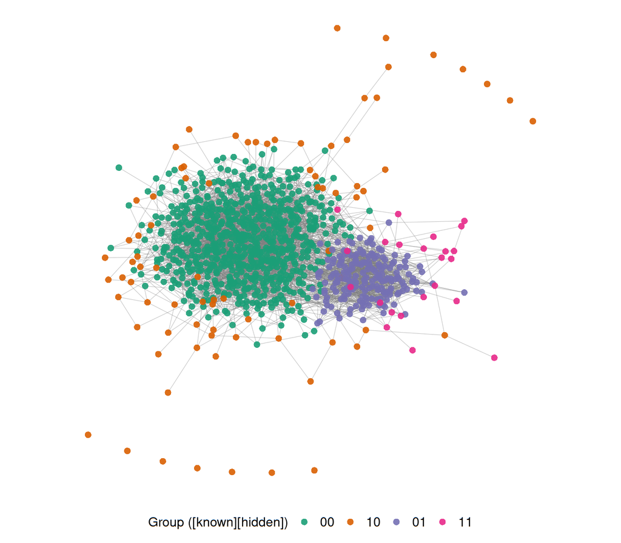

## Inquiries

- **Implementation:** Provide a well documented package that implements sampling and estimation strategies (both at study and meta levels): [gsyunyaev.com/hiddenmeta](https://gsyunyaev.com/hiddenmeta/)
1. Population network simulated with `get_study_population()`
2. Estimands calculated with `get_study_estimands()`

Study-level estimands

| Inquiry | Estimand |
| --- | --- |
| known_size | 105.000 |
| known_prev | 0.105 |
| hidden_size | 202.000 |
| hidden_prev | 0.202 |

## Data strategies

- **Implementation:** Provide a well documented package that implements sampling and estimation strategies (both at study and meta levels): [gsyunyaev.com/hiddenmeta](https://gsyunyaev.com/hiddenmeta/)
1. Population network simulated with `get_study_population()`
2. Estimands calculated with `get_study_estimands()`
3. Sampling simulated with `sample_rds()` / `sample_pps()` / `sample_tls()`

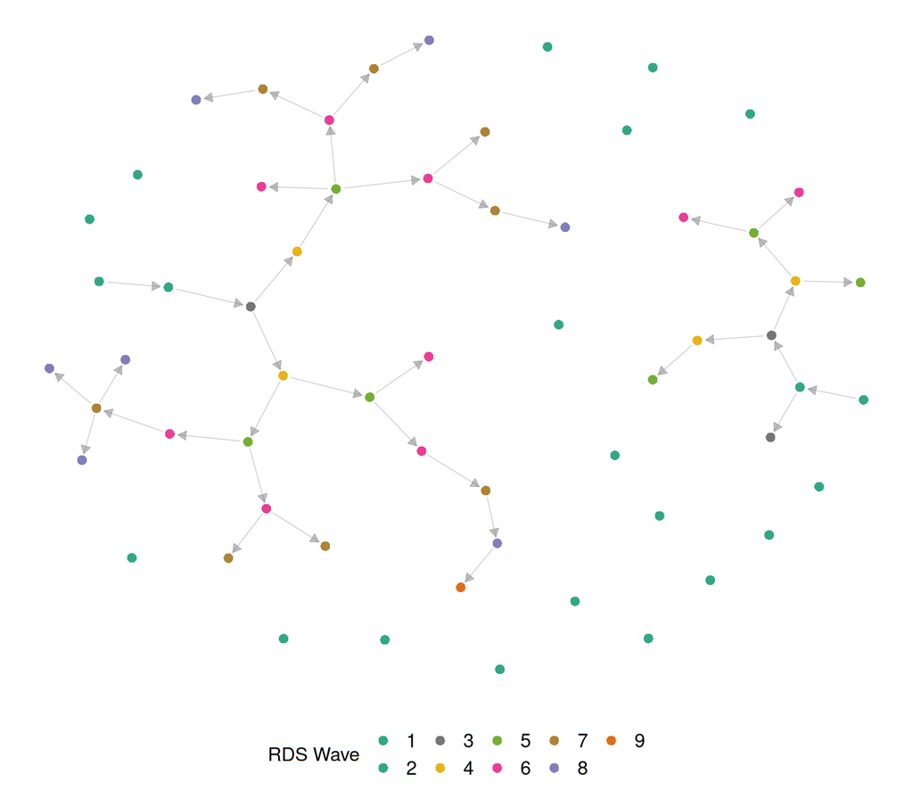

## Data strategies

- **Implementation:** Provide a well documented package that implements sampling and estimation strategies (both at study and meta levels): [gsyunyaev.com/hiddenmeta](https://gsyunyaev.com/hiddenmeta/)
1. Population network simulated with `get_study_population()`
2. Estimands calculated with `get_study_estimands()`
3. Sampling simulated with `sample_rds()` / `sample_pps()` / `sample_tls()`

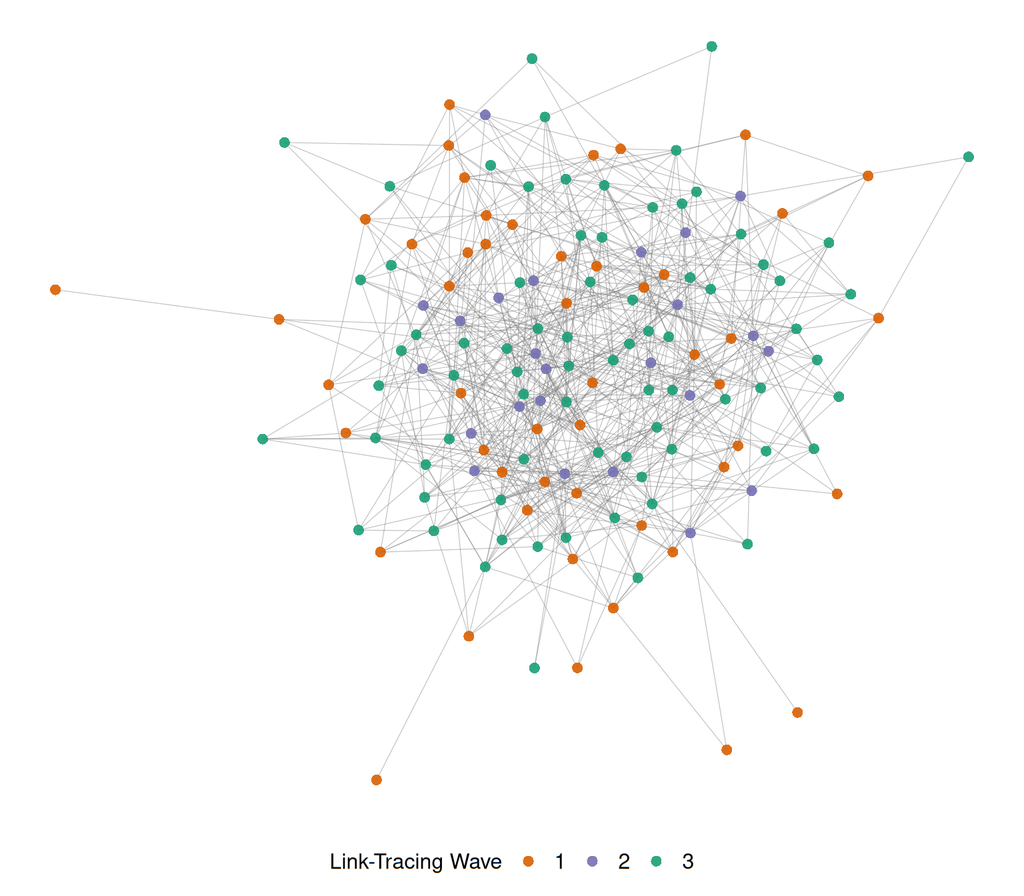

## Data strategies

- **Implementation:** Provide a well documented package that implements sampling and estimation strategies (both at study and meta levels): [gsyunyaev.com/hiddenmeta](https://gsyunyaev.com/hiddenmeta/)
1. Population network simulated with `get_study_population()`
2. Estimands calculated with `get_study_estimands()`
3. Sampling simulated with `sample_rds()` / `sample_pps()` / `sample_tls()`

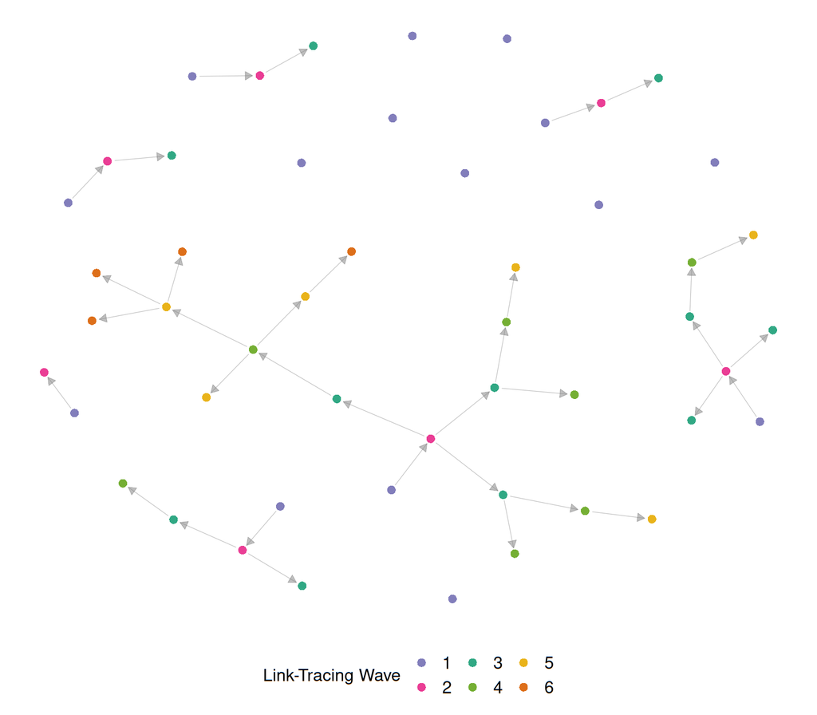

## Answer strategies

- **Implementation:** Provide a well documented package that implements sampling and estimation strategies (both at study and meta levels): [gsyunyaev.com/hiddenmeta](https://gsyunyaev.com/hiddenmeta/)
1. Population network simulated with `get_study_population()`
2. Estimands calculated with `get_study_estimands()`
3. Sampling simulated with `sample_rds()` / `sample_pps()` / `sample_tls()`
4. Estimates from samples with `get_study_est_*()`

## Answer strategies: Prevalence

- **Implementation:** Provide a well documented package that implements sampling and estimation strategies (both at study and meta levels): [gsyunyaev.com/hiddenmeta](https://gsyunyaev.com/hiddenmeta/)

Prevalence estimation methods

| Sampling | Estimation | Method references | [R] Package |
| --- | --- | --- | --- |
| **PPS** | **HT**: Horvitz-Thompson estimator of *prevalence* with re-scaled bootstrap standard errors | Rust and Rao (1996) | Self-coded + `surveybootstrap` (Feehan and Salganik 2023) |
| **TLS** | **HT**: Horvitz-Thompson estimator of *prevalence* with re-scaled bootstrap standard errors (Rust and Rao 1996) | Rust and Rao (1996) | Self-coded + `surveybootstrap` (Feehan and Salganik 2023) |
| **RDS** | **SS**: Sequential sampling estimator of *prevalence* | Gile (2011) | `RDS` (Mark S. Handcock et al. 2023) |
| **RDS+/LTS** | **LINK**: Link-tracing *prevalence* estimator based on snowball sample | Vincent and Thompson (2022) | Self-coded based on Vincent and Thompson (2022) |

## Answer strategies: Population size

- **Implementation:** Provide a well documented package that implements sampling and estimation strategies (both at study and meta levels): [gsyunyaev.com/hiddenmeta](https://gsyunyaev.com/hiddenmeta/)

Population size estimation methods

| Sampling | Estimation | Method references | [R] Package |
| --- | --- | --- | --- |
| **PPS** | **NSUM**: Network scale-up estimator of *population size* with re-scaled bootstrap standard errors | Killworth et al. (1998); Rust and Rao (1996) | `networkreporting` (Feehan and Salganik 2016) + `surveybootstrap` (Feehan and Salganik 2023) |
| **TLS** | **NSUM**: Network scale-up estimator of *population size* with re-scaled bootstrap standard errors (Killworth et al. 1998; Rust and Rao 1996) | Killworth et al. (1998); Rust and Rao (1996) | `networkreporting` (Feehan and Salganik 2016) + `surveybootstrap` (Feehan and Salganik 2023) |
| **TLS** | **RECAP ***: Mark-recapture estimator of *population size* with parametric standard errors | Hickman et al. (2006) | `Rcapture` (Baillargeon and Rivest 2007) |
| **RDS** | **SSPSE**: Bayesian sequential sampling model of *population size* | Mark S. Handcock, Gile, and Mar (2014) | `sspse` (Mark S. Handcock et al. 2022) |
| **RDS** | **CHORDS**: Epidemiological model for *population size* estimation | Berchenko, Rosenblatt, and Frost (2017) | `chords` (Berchenko, Rosenblatt, and Frost 2017) |
| **RDS** | **MULTIPLIER** *: Service-multiplier *population size* estimator with bootstrap re-sampling standard errors | Hickman et al. (2006); Salganik (2006) | Self-coded + `surveybootstrap` (Feehan and Salganik 2023) |
| **RDS+/LTS** | **LINK**: Link-tracing *population size* estimator based on snowball sample | Vincent and Thompson (2022) | Self-coded based on Vincent and Thompson (2022) |
| **RDS+/LTS** | **MSE**: Link-tracing *population size* estimator based on multiple link-tracing samples | Vincent and Thompson (2017) | Self-coded based on Vincent and Thompson (2017) |

## Answer strategies: Comparison with study estimates

- **Implementation:** Provide a well documented package that implements sampling and estimation strategies (both at study and meta levels): [gsyunyaev.com/hiddenmeta](https://gsyunyaev.com/hiddenmeta/)
- Running estimation implemented in the `hiddenmeta` package is straightforward…
  - …once data is in shape. Currently data is in shape for this for two teams.

**Example code for estimation**

```r
hiddenmeta::get_study_est_ss(
      data = jhu_pakistan,
      sampling_frame =  "known1",
      hidden_var = "hidden",
      total_var = "total",
      n_coupons = 3,
      prefix = "rds",
      label = "rds_ss")


hiddenmeta::get_study_est_ht(
      data = umass_tunisia,
      hidden_var = "hidden",
      survey_design = ~ tls_cluster,
      weight_var = "tls_weight",
      prefix = "tls",
      label = "tls_ht")
```

- The results do not always align with what teams produced…
  - …possibly due to data re-coding or model fine-tuning

Comparison of estimates from `hiddenmeta` to study estimates

| Study | Inquiry | Sample | Estimator | Estimates Team | Estimates Replication | Std. Errors Team | Std. Errors Replication |
| --- | --- | --- | --- | --- | --- | --- | --- |
| jhu_pakistan | hidden_prev2 | rds | ss | 0.255 | 0.457 | 0.023 | 0.04 |
| jhu_pakistan | hidden_size2 | pps | ht |  | 27400 |  | 3208 |
| jhu_pakistan | hidden_prev2 | pps | ht | 0.125 | 0.196 | 0.019 | 0.023 |
| umass_tunisia | hidden_size2 | tls | ht |  | 1383 |  | 208 |
| umass_tunisia | hidden_prev2 | tls | ht | 0.238 | 0.22 | 0.013 | 0.033 |
| umass_tunisia | hidden_size2 | tls | recap |  | 3148 |  | 870 |
| umass_tunisia | hidden_size2 | tls | mse |  | 3360 |  | 1048 |

# Meta-analysis models

## Meta-level

- **Implementation:** Provide a well documented package that implements sampling and estimation strategies (both at study and meta levels): [gsyunyaev.com/hiddenmeta](https://gsyunyaev.com/hiddenmeta/)

```r
data {
  int<lower=0> N;
  int<lower=0> K;
  int<lower=0> n_ests;
  real<lower=0> alpha_prior_mean[N];
  real<lower=0> alpha_prior_sd[N];
  real<lower=0> bias_prior_mean[K];
  real<lower=0> bias_prior_sd[K];
  int<lower=0> site[n_ests];
  int<lower=0> design[n_ests];
  vector<lower=0>[n_ests] ests;
  vector<lower=0>[n_ests] ses;
}
parameters { }
model { }
```

## Meta-level: Stan model

- **Implementation:** Provide a well documented package that implements sampling and estimation strategies (both at study and meta levels): [gsyunyaev.com/hiddenmeta](https://gsyunyaev.com/hiddenmeta/)

```r
data {
  int<lower=0> N;
  int<lower=0> K;
  int<lower=0> n_ests;
  real<lower=0> alpha_prior_mean[N];
  real<lower=0> alpha_prior_sd[N];
  real<lower=0> bias_prior_mean[K];
  real<lower=0> bias_prior_sd[K];
  int<lower=0> site[n_ests];
  int<lower=0> design[n_ests];
  vector<lower=0>[n_ests] ests;
  vector<lower=0>[n_ests] ses;
}
parameters {
  vector<lower=0.01>[K] beta;
  vector<lower=0,upper=1>[N] alpha;
}
model { }
```

## Meta-level: Stan model

- **Implementation:** Provide a well documented package that implements sampling and estimation strategies (both at study and meta levels): [gsyunyaev.com/hiddenmeta](https://gsyunyaev.com/hiddenmeta/)

```r
data {
  int<lower=0> N;
  int<lower=0> K;
  int<lower=0> n_ests;
  real<lower=0> alpha_prior_mean[N];
  real<lower=0> alpha_prior_sd[N];
  real<lower=0> bias_prior_mean[K];
  real<lower=0> bias_prior_sd[K];
  int<lower=0> site[n_ests];
  int<lower=0> design[n_ests];
  vector<lower=0>[n_ests] ests;
  vector<lower=0>[n_ests] ses;
}
parameters {
  vector<lower=0.01>[K] beta;
  vector<lower=0,upper=1>[N] alpha;
}
model {
  target += normal_lpdf(ests | beta[design].*alpha[site], ses);
  alpha ~ normal(alpha_prior_mean, alpha_prior_sd);
  beta ~ lognormal(log(beta_prior_mean), beta_prior_sd);
}
```

- likelihood of a given estimate $\hat{\alpha}_{ij}$ for estimand $\alpha_i$ using method $j$ in location $i$ is
  $$\phi(\hat{\alpha}_{ij}|\beta_j\alpha_{i}, \hat{\sigma}_{ij})$$

**Note**: we assume that the standard errors correctly estimate the standard deviation of the sampling distribution of the estimate (even if the estimate is unbiased)

## Meta-level: Stan model

- **Implementation:** Provide a well documented package that implements sampling and estimation strategies (both at study and meta levels): [gsyunyaev.com/hiddenmeta](https://gsyunyaev.com/hiddenmeta/)

```r
data {
  int<lower=0> N;
  int<lower=0> K;
  int<lower=0> n_ests;
  real<lower=0> alpha_prior_mean[N];
  real<lower=0> alpha_prior_sd[N];
  real<lower=0> bias_prior_mean[K];
  real<lower=0> bias_prior_sd[K];
  int<lower=0> site[n_ests];
  int<lower=0> design[n_ests];
  vector<lower=0>[n_ests] ests;
  vector<lower=0>[n_ests] ses;
}
parameters {
  vector<lower=0.01>[K] beta;
  vector<lower=0,upper=1>[N] alpha;
}
model {
  target += normal_lpdf(ests | beta[design].*alpha[site], ses);
  alpha ~ normal(alpha_prior_mean, alpha_prior_sd);
  beta ~ lognormal(log(beta_prior_mean), beta_prior_sd);
}
```

- Prior on $\alpha$ (prevalence/population size) is
  $$\alpha_i \sim f(\mu_{\alpha, i}, {\sigma}_{\alpha, i}),$$
  where the $\mu_{\alpha, i}$ is gathered from teams, $\sigma_{\alpha, i}$ is large, and $f$ denotes the normal distribution.
- Note that we assume no relation between different elements of $\alpha$—that is we do not make use of a prior distribution on prevalence “in general.”

## Meta-level: Stan model

- **Implementation:** Provide a well documented package that implements sampling and estimation strategies (both at study and meta levels): [gsyunyaev.com/hiddenmeta](https://gsyunyaev.com/hiddenmeta/)

```r
data {
  int<lower=0> N;
  int<lower=0> K;
  int<lower=0> n_ests;
  real<lower=0> alpha_prior_mean[N];
  real<lower=0> alpha_prior_sd[N];
  real<lower=0> bias_prior_mean[K];
  real<lower=0> bias_prior_sd[K];
  int<lower=0> site[n_ests];
  int<lower=0> design[n_ests];
  vector<lower=0>[n_ests] ests;
  vector<lower=0>[n_ests] ses;
}
parameters {
  vector<lower=0.01>[K] beta;
  vector<lower=0,upper=1>[N] alpha;
}
model {
  target += normal_lpdf(ests | beta[design].*alpha[site], ses);
  alpha ~ normal(alpha_prior_mean, alpha_prior_sd);
  beta ~ lognormal(log(beta_prior_mean), beta_prior_sd);
}
```

- Prior on $\beta_j$ (bias) is
  $$\beta_j \sim g(\mu_{\beta_j}, {\sigma}_{\beta_j}),$$
  where the $\mu_{\beta_j}$ is gathered from teams, $\sigma_{\beta_j}$ is generally large, and $g$ denotes the log-normal distribution.
- A tighter variance can be placed on any “benchmark” approach
- We assume no relation between different elements of $\beta$ – that is we do not make use of a prior distribution about biases of different methods “in general.”

# Priors

## Disagreements about bias

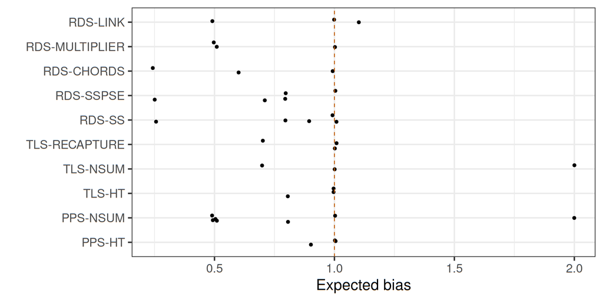

Distribution of expected bias across respondents

- Most respondents expected that most methods would underestimate prevalence
- Some expected rds would especially underestimate prevalence
- One expected all methods would be unbiased
- `PPS-HT` has the tightest distribution centered close to 1

## Uncertainty about bias

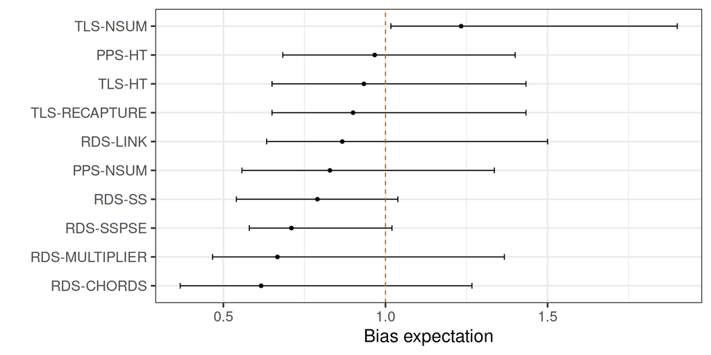

Average bias expectation with average lower and upper bounds of credibility intervals

- There is considerable ex ante uncertainty regarding the performance of methods
- In almost all cases “average bounds” include 1
- Only for `TLS-NSUM` was the “average” credibility interval entirely above 1

# Main meta-analysis results

## Data

- Sample of estimates depends on estimands: prevalence (threshold 1 / threshold 2 / both), size (hidden / known)
  - e.g. for prevalence (threshold 1)

| Study | LTS-HCG | LTS-NE4NS | LTS-NE4NS2 | LTS-VH | PPS-HT | RDS-SS | TLS-HT | TLS-RMARK |
| --- | --- | --- | --- | --- | --- | --- | --- | --- |
| Brazil (FF) |  |  |  |  |  | x |  |  |
| Pakistan (JHU) |  |  |  |  | x | x |  |  |
| Morocco (NORC) |  | x |  |  |  |  |  | x |
| Costa Rica (NYU) | x | x | x | x | x |  |  |  |
| Tanzania (NYU) | x | x | x | x | x |  |  |  |
| Tunisia (UMass) |  |  |  |  |  |  | x | x |

## Main meta-analysis results: Threshold 1 (Biases)

```r
prif_estimates |>
  filter(inquiry == "hidden_prev1") |>
  get_meta_estimates()
```

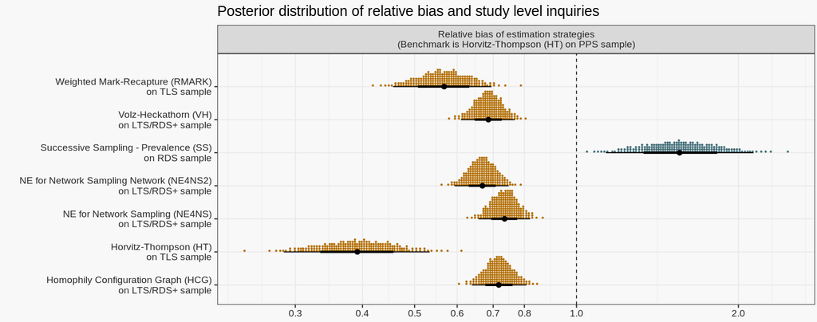

## Main meta-analysis results: Threshold 1 (Prevalence)

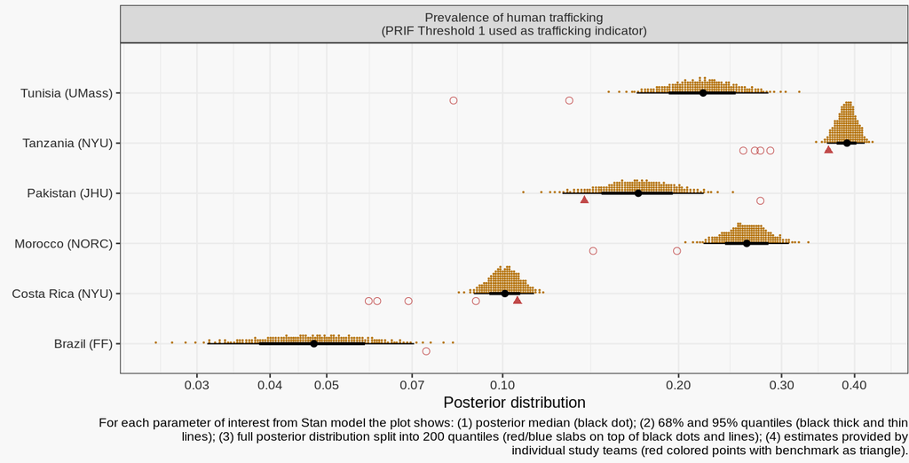

## Main meta-analysis results: Threshold 2 (Biases)

```r
prif_estimates |>
  filter(inquiry == "hidden_prev2") |>
  get_meta_estimates()
```

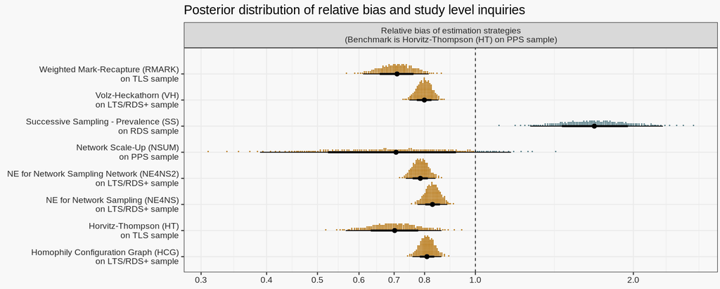

## Main meta-analysis results: Threshold 2 (Prevalence)

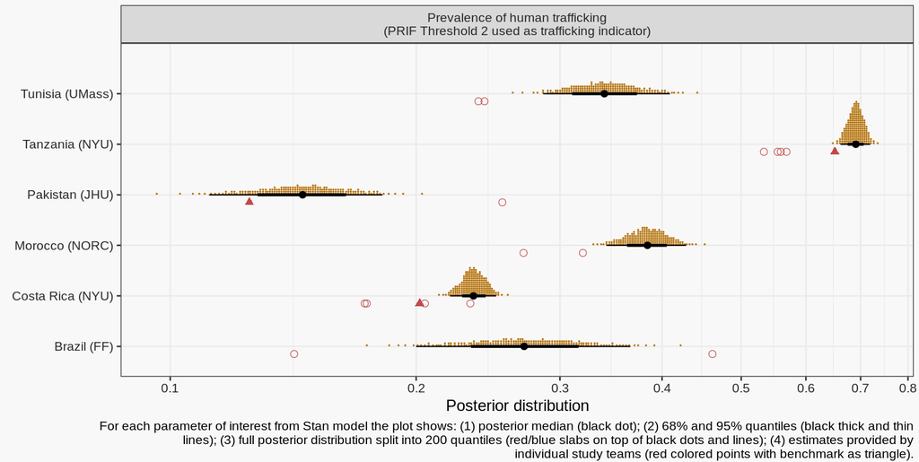

## Estimated bias vs. priors

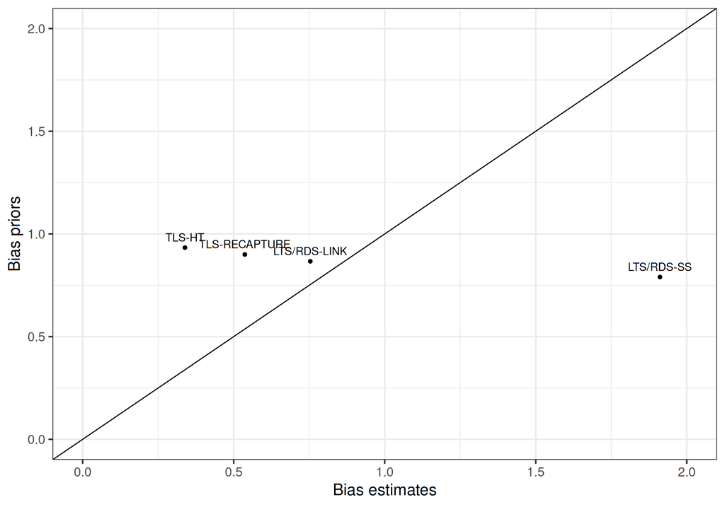

Estimated bias vs. bias priors

- Estimated biases exhibit more variance than priors on biases

# Alternative model: Allow arbitrary heterogeneity

## Approach

Instead of assuming that the relative bias of a method $\beta_{j}$ is constant, we assume that at each site it is a draw from a distribution:
$$\beta_{j} \sim f(\beta^*_{j}, \sigma_{j})$$
We get to estimate both $\beta^*_{j}$ – the *expected* relative bias, and $\sigma_{j}$: the heterogeneity in relative bias.

## Bias comparisons across models

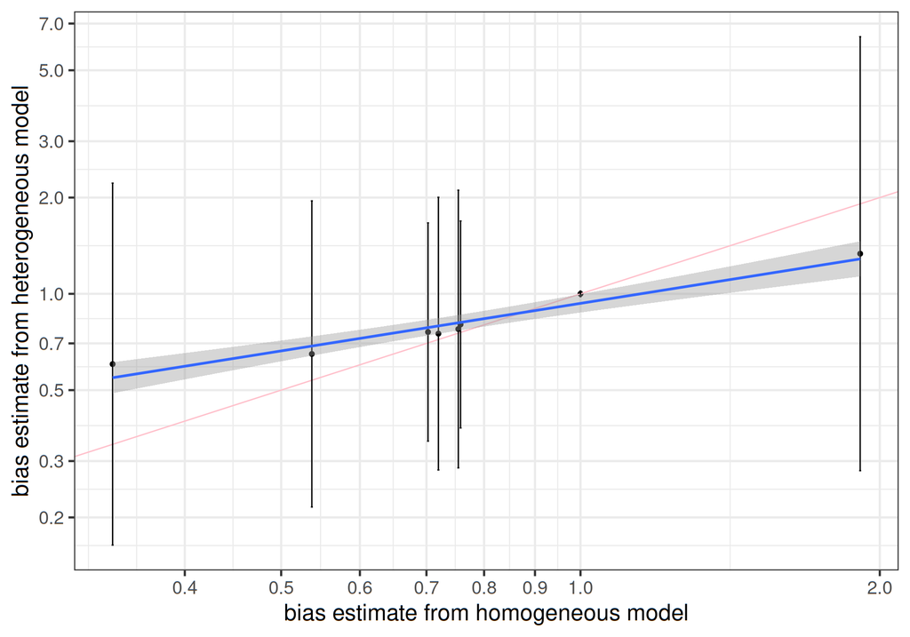

Estimated bias comparisons

- These correlate. Basic message though is that the heterogeneous model is consistent with strong heterogeneity: We entertain the possibility that every method could be an overestimate or an underestimate.
- This model has many parameters for not so many data points $\Rightarrow$ prior sensitivity

## Prevalence estimates from two models

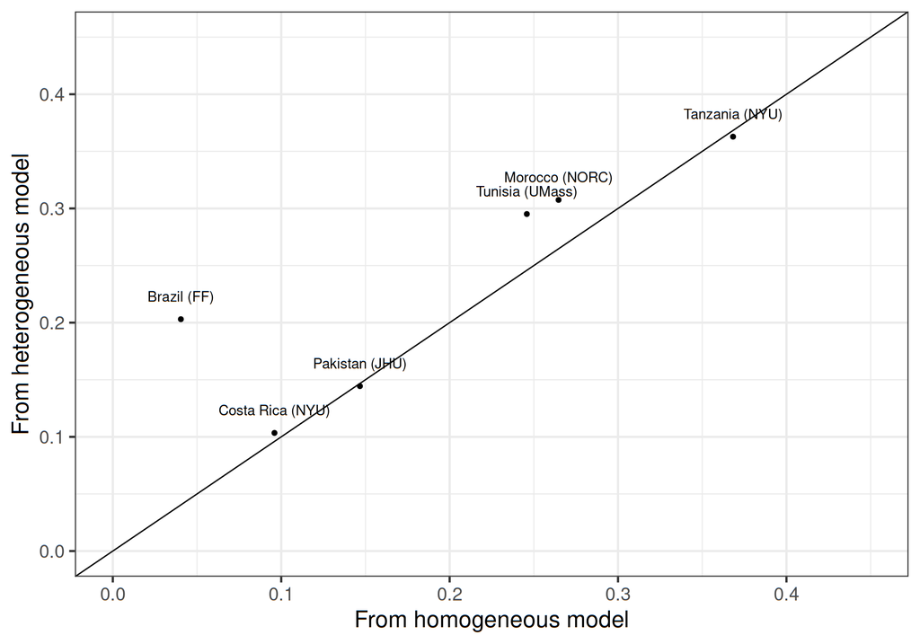

Prevalence estimates from two models

- Biggest difference is in Brazil which sees less adjustment in heterogeneous model

## Cost benefit analysis

- Plot estimates of root mean squared error (RMSE) against approximate costs of each sampling strategy provided by teams to identify strategies that are undominated *wrt* costs and error.
- Interested in assessing the cost-error *frontier*
- To estimate RMSE we use the expression for mean square error:

$$\mathrm{MSE}(\hat\beta) = \mathrm{Var}(\hat\beta) + \mathrm{Bias}(\hat\beta,\beta)^2$$

- To assess Bias we use the difference between the posterior prevalence estimate and the raw estimate in question.

| Study | Type of sample | Sample size | Costs (in 1000 USD) |
| --- | --- | --- | --- |
| Brazil (FF) | PPS | 1000 | 50 |
| Brazil (FF) | RDS | 600 | 100 |
| Pakistan (JHU) | PPS | 800 | 45 |
| Pakistan (JHU) | RDS | 500 | 65 |
| Morocco (NORC) | LTS/RDS+ | 989 | 350 |
| Morocco (NORC) | TLS/TLS-RECAP | 1067 | 450 |
| Costa Rica (NYU) | PPS | 1017 | 79 |
| Costa Rica (NYU) | LTS/RDS+ | 1009 | 212 |
| Tanzania (NYU) | LTS/RDS+ | 788 | 15 |
| Tanzania (NYU) | PPS | 1052 | 55 |
| Tunisia (UMass) | TLS-RECAP | 1016 | 80 |
| Tunisia (UMass) | TLS | 1029 | 100 |

## Cost-benefit analysis by study

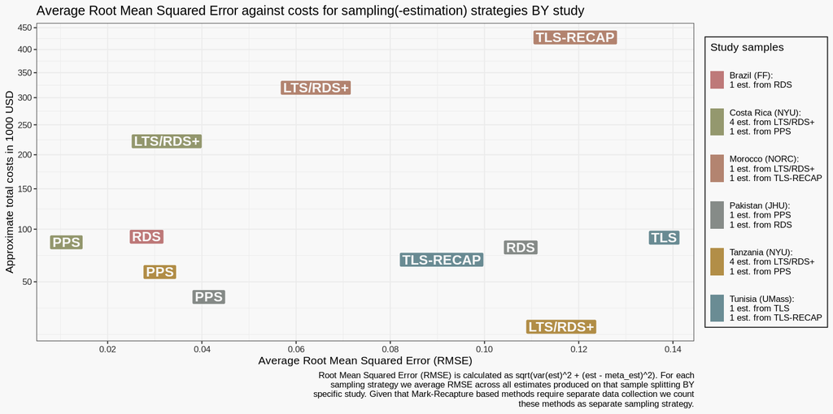

- Note that the frontier is covered largely by PPS. LTS/RDS+ (Tanzania) is also on the frontier here with low cost, but large error (from our estimates).

## Cost-benefit analysis by strategy

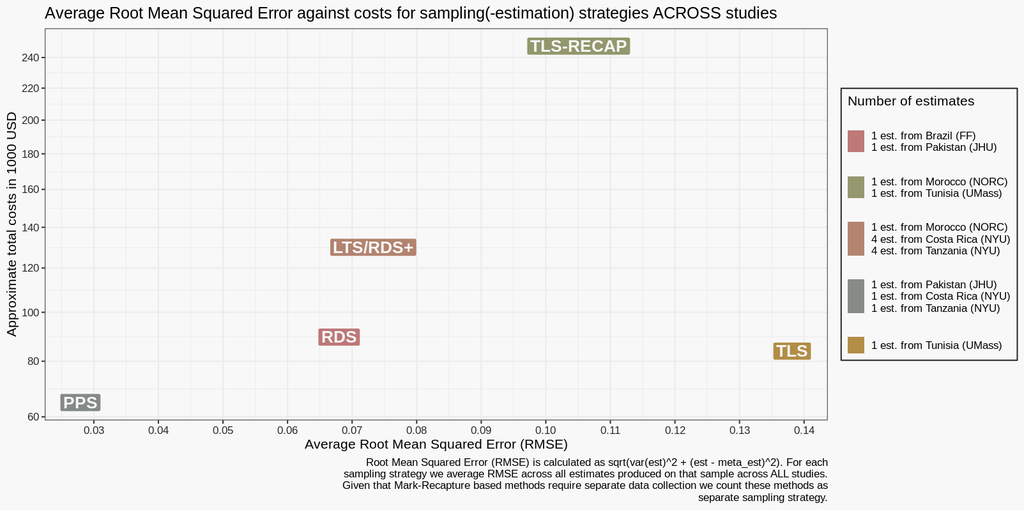

# Dashboard

## Interactive meta-analysis

- The meta-analysis results are preliminary:
  - Estimates from some teams were not included in the meta-analysis dataset
  - The costs of each method might need to be adjusted
  - The priors on study level inquiries as well as relative biases might need to be adjusted
- We built an interactive Shiny dashboard for everyone to be able to explore and adjust data and priors
- We encourage everyone to access the dashboard and *play* with it here: shiny2.wzb.eu/syunyaev/hiddenmetashiny/

## Interactive meta-analysis

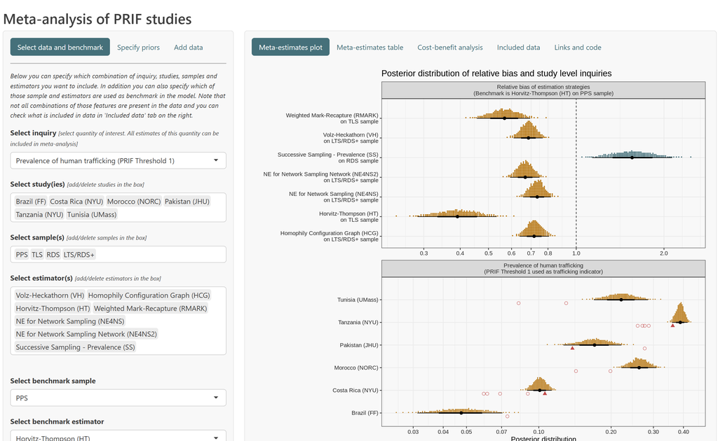

# Wrap up

## Worries and todos

#### Todos

- Replication work not completed: please bring your data!
- Still relatively low overlap ($n$ per method); we want to improve this (bring your data and lets implement the NSUMs)
- Implement *structured* heterogeneity analysis: for instance, based on types of networks

#### Worries and issues

- We are seeing some variation in results as a function of thresholds
- Seems clear we need to deviate from PAP
- We are assuming independence of samples in each study but this is not right

## Onwards

- We are setting up the dashboard so that you can add more data and the meta-analysis updates automatically.
- The dream is as you do more studies you use multiple methods and you feed into this “rolling meta-analysis”
  - Who will curate?
  - What documentation is needed to join the club?

## Conclusion and reflections

#### High level conclusion

- We know different people here love RDS, Link tracing, and TLS
- There are good prior reasons for each of these
- But meta-analysis suggests HT (more than) competitive
  - Others seem to underestimate in general
  - Others appear costly

#### Model performance

- Bias appear to be demonstrably *not* homogeneous across studies, counter to our pre-registered model
- Sensitivity to priors, thresholds

## Reflections

- Even if estimates similar, if these are getting at different parts of the population then these are not substitutable: approach to get prevalence of subgroups within target population
- What finer data to use to assess optimal “mixing”?
- What else to take into account for decision between methods (e.g. Pakistan team described RDS as safer–this not captured in our analysis. )

# Questions

## References

Baillargeon, Sophie, and Louis-Paul Rivest. 2007. “Rcapture: Loglinear Models for Capture-Recapture in r.” *Journal of Statistical Software* 19: 1–31.

Berchenko, Yakir, Jonathan D. Rosenblatt, and Simon D. W. Frost. 2017. “Modeling and Analyzing Respondent-Driven Sampling as a Counting Process.” *Biometrics* 73 (4): 1189–98. https://doi.org/10.1111/biom.12678.

Feehan, DM, and MJ Salganik. 2016. “Networkreporting: Tools for Using Network Reporting Estimators [r Package Version 0.1.1].”

———. 2023. “Surveybootstrap: Tools for the Bootstrap with Survey Data [r Package Version 0.0.3].”

Gile, Krista J. 2011. “Improved Inference for Respondent-Driven Sampling Data with Application to HIV Prevalence Estimation.” *Journal of the American Statistical Association* 106 (493): 135–46.

Handcock, Mark S., Krista J. Gile, and Corinne M. Mar. 2014. “Estimating Hidden Population Size Using Respondent-Driven Sampling Data.” *Electronic Journal of Statistics* 8 (1): 1491–521. https://doi.org/10.1214/14-EJS923.

Handcock, Mark S, Krista J Gile, Ian E Fellows, and W Whipple Neely. 2023. “RDS: Respondent-Driven Sampling Package.”

Handcock, Mark S, Krista J Gile, Brian Kim, and Katherine R McLaughlin. 2022. “Sspse: Estimating Hidden Population Size Using Respondent Driven Sampling.”

Hickman, Matthew, Vivian Hope, Lucy Platt, Vanessa Higgins, Mark Bellis, Tim Rhodes, Colin Taylor, and Kate Tilling. 2006. “Estimating Prevalence of Injecting Drug Use: A Comparison of Multiplier and Capture-Recapture Methods in Cities in England and Russia.” *Drug and Alcohol Review* 25 (2): 131–40.

Killworth, Peter D, Eugene C Johnsen, Christopher McCarty, Gene Ann Shelley, and H Russell Bernard. 1998. “A Social Network Approach to Estimating Seroprevalence in the United States.” *Social Networks* 20 (1): 23–50.

Rust, Keith F, and JNK Rao. 1996. “Variance Estimation for Complex Surveys Using Replication Techniques.” *Statistical Methods in Medical Research* 5 (3): 283–310.

Salganik, Matthew J. 2006. “Variance Estimation, Design Effects, and Sample Size Calculations for Respondent-Driven Sampling.” *Journal of Urban Health* 83 (Suppl 1): 98.

Vincent, Kyle, and Steve Thompson. 2017. “Estimating Population Size with Link-Tracing Sampling.” *Journal of the American Statistical Association* 112 (519): 1286–95.

———. 2022. “Estimating the Size and Distribution of Networked Populations with Snowball Sampling.” *Journal of Survey Statistics and Methodology* 10 (2): 397–418.